# Project 1 : NHGIS and the US county population

## **Task 2: All counties**

```r
# get API-key: https://account.ipums.org/api_keys
mykey <- readLines("/Applications/Documents/Master 1 Econométrie Statistique/Semestre 2/Data_Viz_S2/Data/ipums_api_key.txt")
# Save key in .Renviron for use across sessions
set_ipums_api_key(mykey, save = TRUE)

# "tl": Census Bureau TIGER/Line
nhgis_ext <- define_extract_nhgis(
  description = "County shapefiles (2020)",
  shapefiles = "us_county_2020_tl2020"
)
nhgis_ext_submitted <- submit_extract(nhgis_ext)
nhgis_ext_complete <- wait_for_extract(nhgis_ext_submitted)
filepath <- download_extract(nhgis_ext_submitted,
                             download_dir = "/Applications/Documents/Master 1 Econométrie Statistique/Semestre 2/Data_Viz_S2/Data/Source/")
```

```r
shape_us <- read_ipums_sf("/Applications/Documents/Master 1 Econométrie Statistique/Semestre 2/Data_Viz_S2/Data/Source/nhgis0001_shape.zip")
# contiguous states / counties
shape_us %>%
  mutate(STATEFP = as.integer(STATEFP)) %>%
  filter(STATEFP < 57) %>%
  filter(!(STATEFP %in% c(2,15))) ->
  shape_us

glimpse(shape_us) # 3,108 x 21
```

```
## Rows: 3,108
## Columns: 21
## $ GISJOIN    <chr> "G0100010", "G0100030", "G0100050", "G0100070", "G0100090",…
## $ STATEFP    <int> 1, 1, 1, 1, 1, 1, 1, 1, 1, 1, 1, 1, 1, 1, 1, 1, 1, 1, 1, 1,…
## $ COUNTYFP   <chr> "001", "003", "005", "007", "009", "011", "013", "015", "01…
## $ COUNTYNS   <chr> "00161526", "00161527", "00161528", "00161529", "00161530",…
## $ GEOID      <chr> "01001", "01003", "01005", "01007", "01009", "01011", "0101…
## $ NAME       <chr> "Autauga", "Baldwin", "Barbour", "Bibb", "Blount", "Bullock…
## $ NAMELSAD   <chr> "Autauga County", "Baldwin County", "Barbour County", "Bibb…
## $ LSAD       <chr> "06", "06", "06", "06", "06", "06", "06", "06", "06", "06",…
## $ CLASSFP    <chr> "H1", "H1", "H1", "H1", "H1", "H1", "H1", "H1", "H1", "H1",…
## $ MTFCC      <chr> "G4020", "G4020", "G4020", "G4020", "G4020", "G4020", "G402…
## $ CSAFP      <chr> "388", "380", NA, "142", "142", NA, NA, NA, "122", NA, "142…
## $ CBSAFP     <chr> "33860", "19300", "21640", "13820", "13820", NA, NA, "11500…
## $ METDIVFP   <chr> NA, NA, NA, NA, NA, NA, NA, NA, NA, NA, NA, NA, NA, NA, NA,…
## $ FUNCSTAT   <chr> "A", "A", "A", "A", "A", "A", "A", "A", "A", "A", "A", "A",…
## $ ALAND      <dbl> 1539634184, 4117656199, 2292160149, 1612188717, 1670259090,…
## $ AWATER     <dbl> 25674812, 1132956041, 50523213, 9572303, 14860281, 6030667,…
## $ INTPTLAT   <chr> "+32.5322367", "+30.6592183", "+31.8702531", "+33.0158929",…
## $ INTPTLON   <chr> "-086.6464395", "-087.7460666", "-085.4051035", "-087.12714…
## $ Shape_Leng <dbl> 210512.6, 637811.6, 272036.6, 190851.1, 242282.0, 210654.5,…
## $ Shape_Area <dbl> 1565309074, 4264564259, 2342683550, 1621761112, 1685119450,…
## $ geometry   <MULTIPOLYGON [m]> MULTIPOLYGON (((895625.2 -5..., MULTIPOLYGON (…
```

We extract shape_us file

```r
# Step 1: Add a total population column
data_2010 <- data_2010 %>%
  mutate(pop_total = pop_white + pop_black + pop_native + pop_asian + pop_other + pop_mixed)
colnames(data_2010)
```

```
##  [1] "GISJOIN"    "STATE"      "STATEA"     "COUNTY"     "pop_white"
##  [6] "pop_black"  "pop_native" "pop_asian"  "pop_other"  "pop_mixed"
## [11] "pop_total"
```

```r
# Merge on the GISJOIN key
map_data <- shape_us %>%
  left_join((data_2010), by = "GISJOIN")

# Display the first rows of the pop_total column in map_data
head(map_data$pop_total)
```

```
## [1]  54571 182265  27457  22915  57322  10914
```

```r
# Define the number of population categories
n_classes <- 7
bks <- classInt::classIntervals(c(min(map_data$pop_total) - .00001,
                                  map_data$pop_total),
                                n=n_classes, style = "quantile")$brks
# Create categorical population variable based on intervals
map_data  %>%
  mutate(pop_total_cat = cut(pop_total, bks)) ->
  map_data

levels(map_data$pop_total_cat)
```

```
## [1] "(82,7.04e+03]"       "(7.04e+03,1.33e+04]" "(1.33e+04,2.1e+04]"
## [4] "(2.1e+04,3.34e+04]"  "(3.34e+04,5.6e+04]"  "(5.6e+04,1.37e+05]"
## [7] "(1.37e+05,9.82e+06]"
```

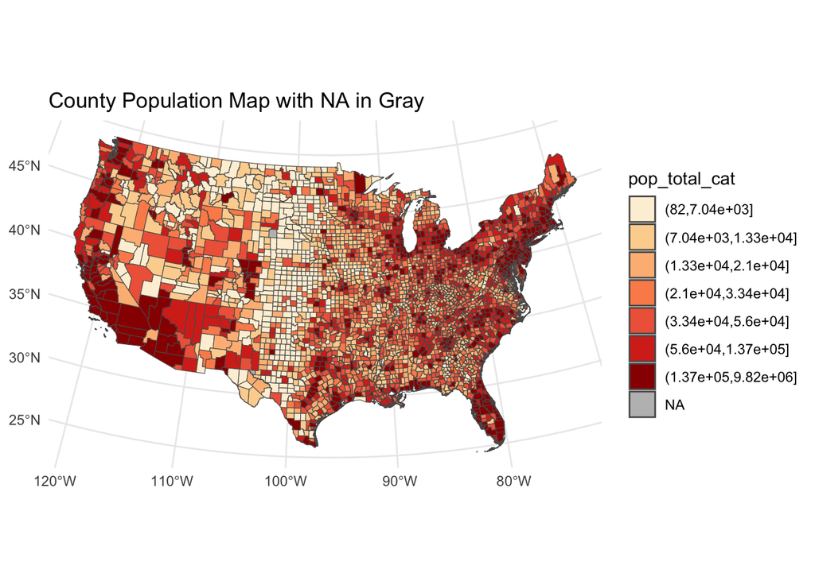

```r
### Static Map with ggplot2

ggplot(data = map_data) +
  geom_sf(aes(fill = pop_total_cat)) +
  scale_fill_brewer(palette = "OrRd", na.value = "gray") +  # Replace NA with gray
  theme_minimal() +
  labs(title = "County Population Map with NA in Gray")
```

We extracts population data by race for each U.S. county in 2010, cleans it, groups races into categories (White, Black, Native, Asian, Other, Mixed), and we calculates a total population per county. Then, it merges this data with a geographic shapefile of U.S. counties.

Total population is classified into 7 categories based on size and visualized first through a static map using ggplot2.

## Task 3: Mapping application into a leaflet application

```r
### Interactive Map with Leaflet

# Safely transform coordinate system to WGS84
map_data_WGS84 <- st_transform(map_data, 4326)

# Create a color palette based on population categories
pal <- leaflet::colorFactor("YlOrRd", domain = map_data_WGS84$pop_total_cat)

# Build the interactive map
leaflet(map_data_WGS84) %>%
  addTiles() %>%
  addPolygons(
    fillColor = ~pal(pop_total_cat),
    fillOpacity = 0.8,
    stroke = FALSE,
    popup = ~paste0(
      "<b>County:</b> ", NAME, "<br>",
      "<b>State:</b> ", STATEFP, "<br>",
      "<b>Population:</b> ", format(pop_total, big.mark = ",")
    )
  ) %>%
  addLegend("bottomright", pal = pal, values = ~pop_total_cat,
            title = "Total Population (categories)",
            opacity = 1)
```

[figure not shown]

[figure not shown]

[figure not shown]

## Task 4 : Generating a dynamic dashboard using Shiny

```r
ui <- fluidPage(
  titlePanel("US county population in 2010"),

  sidebarLayout(
    sidebarPanel(
      selectInput("state", "State:", choices = unique(data_2010$STATE), selected = "Alabama"),
      uiOutput("county_ui")
    ),

    mainPanel(
      leafletOutput("map", height = 400),
      textOutput("county_id"),
      plotOutput("barplots", height = 400)
    )
  )
)

server <- function(input, output, session) {

 # Dynamic county selection by state
  output$county_ui <- renderUI({
    counties <- data_2010 %>%
      filter(STATE == input$state) %>%
      pull(COUNTY) %>%
      unique() %>%
      sort()

    selectInput("county", "County:", choices = counties)
  })

  # Reactive storage for selected county (either via list or map)
  selected_county <- reactiveVal(NULL)

  observeEvent(input$map_shape_click, {
    click <- input$map_shape_click
    if (!is.null(click$id)) {
      county_clicked <- map_data_WGS84 %>%
        filter(GISJOIN == click$id) %>%
        pull(COUNTY) %>% unique()

      state_clicked <- map_data_WGS84 %>%
        filter(GISJOIN == click$id) %>%
        pull(STATE) %>% unique()

      updateSelectInput(session, "state", selected = state_clicked)
      updateSelectInput(session, "county", selected = county_clicked)
    }
  })


  output$map <- renderLeaflet({
    pal <- colorFactor("YlOrRd", domain = map_data_WGS84$pop_total_cat)

    leaflet(map_data_WGS84) %>%
      addTiles() %>%
      addPolygons(
        fillColor = ~pal(pop_total_cat),
        fillOpacity = 0.8,
        stroke = FALSE,
        layerId = ~GISJOIN,
        popup = ~paste0(
          "<b>County:</b> ", COUNTY, "<br>",
          "<b>State:</b> ", STATE, "<br>",
          "<b>Population:</b> ", format(pop_total, big.mark = ",")
        )
      ) %>%
      addLegend("bottomright", pal = pal, values = ~pop_total_cat,
                title = "Total population (categories)", opacity = 1)
  })

  # Barplots for selected county
  output$barplots <- renderPlot({
    req(input$county)

    df <- data_2010 %>%
      filter(STATE == input$state, COUNTY == input$county)

    racial_data <- df %>%
      summarise(
        pop_white = sum(pop_white, na.rm = TRUE),
        pop_black = sum(pop_black, na.rm = TRUE),
        pop_native = sum(pop_native, na.rm = TRUE),
        pop_asian = sum(pop_asian, na.rm = TRUE),
        pop_other = sum(pop_other, na.rm = TRUE)
      ) %>%
      pivot_longer(cols = everything(), names_to = "race", values_to = "population") %>%
      mutate(
        race_label = recode(race,
                            pop_white = "White",
                            pop_black = "Black",
                            pop_native = "Native",
                            pop_asian = "Asian",
                            pop_other = "Other"),
        race_label = factor(race_label, levels = c("White", "Black", "Asian", "Native", "Other"))
      )

    # Couleurs
    set2_colors <- c(
      "White" = "#FF69B4", "Black" = "#556B2F", "Asian" = "#66c2a5",
      "Native" = "#8da0cb", "Other" = "#e78ac3"
    )

    # Barplot 1
    plot1 <- ggplot(racial_data, aes(y = race_label, x = population, fill = race_label)) +
      geom_col() +
      geom_text(aes(label = race_label),
                hjust = ifelse(racial_data$race_label == "Native", -0.1, 1.1),
                color = "black", size = 5) +
      labs(title = paste("County:", input$county), x = "Population", y = NULL) +
      theme_minimal() +
      theme(axis.text.y = element_blank(), axis.ticks.y = element_blank(), legend.position = "none") +
      scale_fill_manual(values = set2_colors) +
      scale_x_continuous(labels = scales::scientific)

    # Barplot 2
    plot2 <- ggplot(racial_data, aes(y = race_label, x = population / 1e7, fill = race_label)) +
      geom_col() +
      geom_text(aes(label = scales::comma(population)),
                hjust = -0.2, color = "black", size = 5) +
      labs(title = "Population share", x = "Population (millions)", y = NULL) +
      theme_minimal() +
      theme(axis.text.y = element_blank(), axis.ticks.y = element_blank(), legend.position = "none") +
      scale_fill_manual(values = set2_colors) +
      scale_x_continuous(labels = scales::comma)

    plot1 + plot2 + plot_layout(ncol = 2)
  })
}

shinyApp(ui, server)
```

[figure not shown]

[figure not shown]

[figure not shown]

This is the end of the project 1. We can continue now with the second project.